# gwasplot: Modern GWAS Visualizations

# Getting started

## Installation

```r
pak::pak("bczech/gwasplot")
```

## Reading data

`read_gwas_table()` auto-detects column names from any delimited file:

```r
library(gwasplot)
library(ggplot2)
data(example_gwas)
example_gwas
```

```
#> A gwas_data object: 5,000 variants across 22 chromosomes
#>   Min p-value: 5.55e-16
#>   Lambda GC:   5.273
#>   Columns:     CHR, BP, SNP, P, BETA, SE, A1, A2, AF
```

Format-specific readers are also available:

```r
gwas <- read_gwas_table("results.txt")
gwas <- read_plink_assoc("results.assoc")
gwas <- read_plink_linear("results.assoc.linear")
gwas <- read_regenie("results.regenie")
gwas <- read_gcta_mlma("results.mlma")
gwas <- read_gemma("results.assoc.txt")
```

Any `data.frame` works directly — just map the columns if needed:

```r
manhattan_plot(my_df, chr = "chrom", bp = "position", p = "pval")
```

# Core plots

## Manhattan plot

```r
manhattan_plot(example_gwas)
```

Label the top hits and adjust colors:

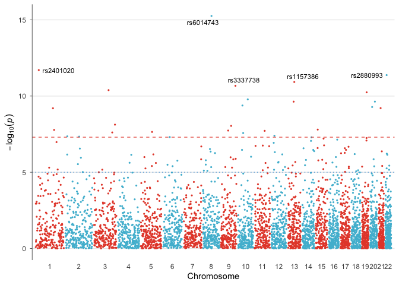

```r
manhattan_plot(
  example_gwas,
  label_top_n = 5,
  colors = gwas_palette("vibrant")
)
```

## QQ plot

P-value distribution with confidence bands and genomic inflation factor:

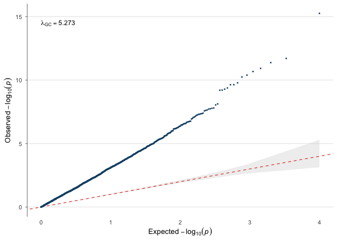

```r
qq_plot(example_gwas, show_lambda = TRUE, ci = 0.95)
```

Stratify by MAF to check whether inflation is driven by rare variants:

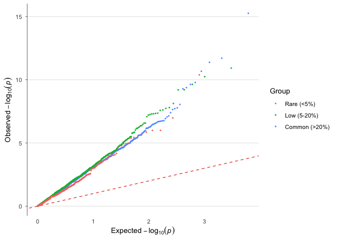

```r
example_gwas$MAF_bin <- cut(
  example_gwas$AF,
  breaks = c(0, 0.05, 0.2, 0.5),
  labels = c("Rare (<5%)", "Low (5-20%)", "Common (>20%)")
)
qq_plot(example_gwas, group = "MAF_bin")
```

## Miami plot

Two GWAS results mirrored vertically — handy for discovery vs replication:

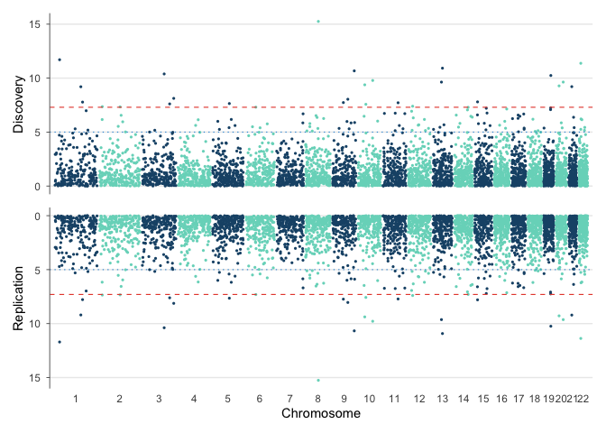

```r
miami_plot(
  example_gwas, example_gwas,
  top_title = "Discovery",
  bottom_title = "Replication"
)
```

## Locus zoom

Zoom into a region of interest:

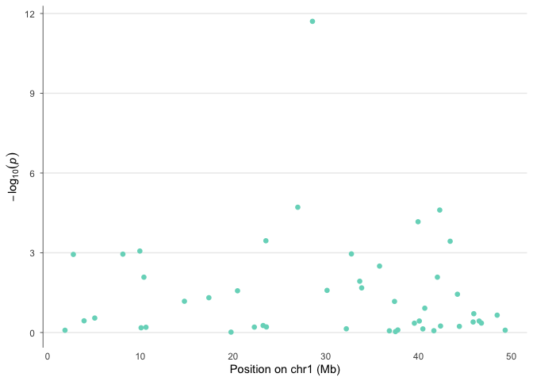

```r
locus_plot(example_gwas, region_chr = 1, region_start = 1e6, region_end = 50e6)
```

# Novel visualizations

## Genome-wide p-value heatmap

Each cell is a genomic bin colored by the minimum p-value it contains. Handles millions of variants without downsampling because it pre-aggregates:

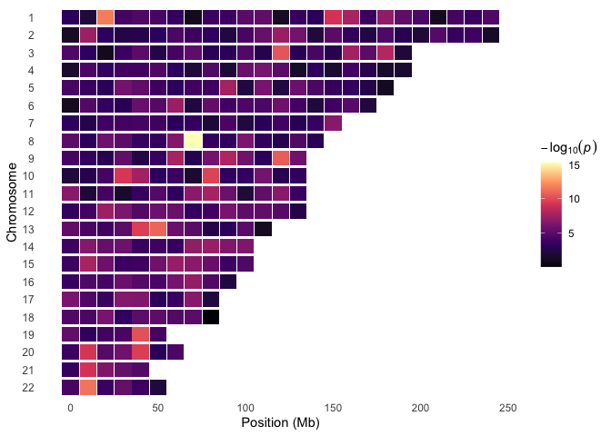

```r
pvalue_heatmap(example_gwas, bin_size = 10e6, palette = "magma")
```

## Effect-size volcano

BETA vs -log10(p) — see direction and magnitude of effect at a glance:

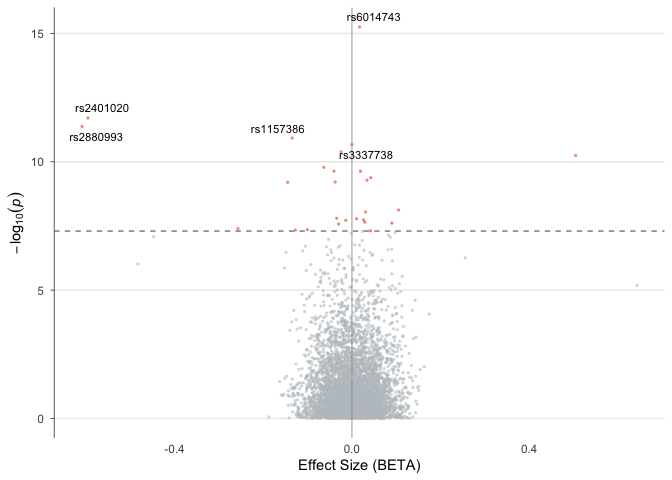

```r
volcano_plot(example_gwas, label_top_n = 5)
```

## Circular Manhattan

Circos-style layout, also supports multiple rings for multi-trait comparison:

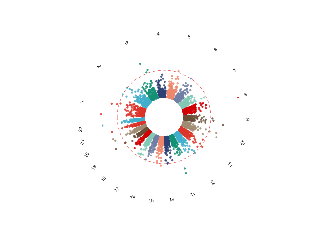

```r
circular_manhattan(example_gwas, colors = gwas_palette("nature"))
```

## Summary dashboard

Multi-panel figure with automatic panel tags (A, B, C, D):

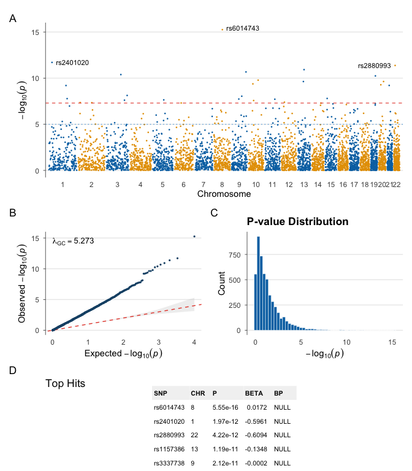

```r
gwas_summary(example_gwas)
```

# Gene annotation and top hits

## Gene labels on peaks

`manhattan_genes()` replaces rs IDs with the nearest gene name from a user-supplied table. In practice you would load this from a GTF file or via biomaRt — here we define a small set by hand:

```r
genes <- data.frame(
  chr = c(1, 2, 5, 7, 11, 15, 19, 22),
  start = c(2e6, 50e6, 80e6, 30e6, 60e6, 40e6, 10e6, 20e6),
  end = c(3e6, 52e6, 85e6, 35e6, 65e6, 45e6, 15e6, 25e6),
  gene = c("MTOR", "NRXN1", "TCF7L2", "CDKAL1", "KCNQ1", "FTO", "LDLR", "COMT")
)

manhattan_genes(example_gwas, genes = genes, gene_p_threshold = 0.001)
```

Arrow-style labels work better when peaks are close together:

```r
manhattan_genes(
  example_gwas, genes = genes,
  gene_p_threshold = 0.001,
  arrow = TRUE, label_face = "italic"
)
```

## Top hits table

`top_hits()` clumps significant SNPs (keeping one lead per 1 Mb window), estimates the cytoband, and optionally maps each to the nearest gene:

```r
top_hits(example_gwas, p_threshold = 0.001, genes = genes, n = 10)
```

```
#> === Top 10 GWAS Hits ===
#>
#>  SNP       CHR BP        P        BETA     nearest_gene cytoband
#>  rs6014743 8    74424666 5.55e-16  0.01719 <NA>         8q8
#>  rs2401020 1    28556629 1.97e-12 -0.59609 <NA>         1p3
#>  rs2880993 22   11313385 4.22e-12 -0.60941 <NA>         22p2
#>  rs1157386 13   55823378 1.19e-11 -0.13479 <NA>         13q6
#>  rs3337738 9   127972728 2.12e-11 -0.00017 <NA>         9q13
#>  rs1794282 3   128764792 4.10e-11 -0.02460 <NA>         3q13
#>  rs3747362 19   41995675 5.70e-11  0.50486 <NA>         19p5
#>  rs2755981 10   85551314 1.64e-10 -0.06352 <NA>         10q9
#>  rs8108424 20   43688532 2.32e-10 -0.04059 <NA>         20p5
#>  rs2527814 13   49885487 2.33e-10  0.01929 <NA>         13p5
```

## Region highlights

Draw a colored band behind a genomic region — useful for marking the MHC, known GWAS loci, or any region of interest:

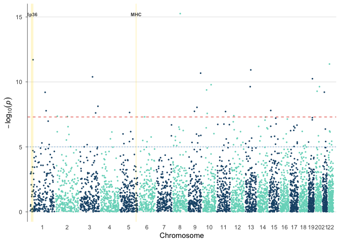

```r
plt <- manhattan_plot(example_gwas)

regions <- data.frame(
  chr = c(6, 1),
  start = c(25e6, 5e6),
  end = c(35e6, 30e6),
  label = c("MHC", "1p36")
)

highlight_regions(plt, regions, color = "#FFD700", alpha = 0.2)
```

# Multi-study comparisons

## Multi-trait Manhattan

Overlay multiple GWAS on one plot. Variants reaching significance in more than one trait are flagged automatically:

```r
set.seed(123)
trait2 <- example_gwas
trait2$P <- runif(nrow(trait2))^3
trait2$P[sample(nrow(trait2), 10)] <- 10^(-runif(10, 5, 10))

multitrait_manhattan(
  BMI = example_gwas,
  Height = trait2,
  colors = "nature",
  highlight_shared = TRUE
)
```

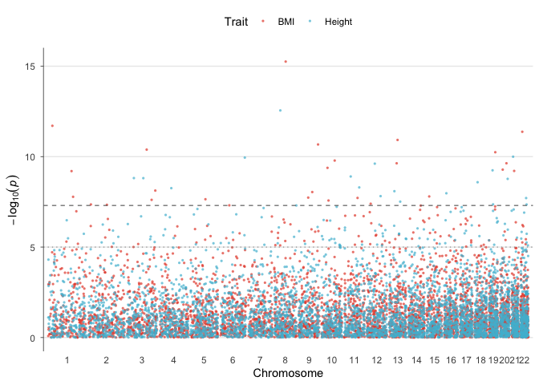

## Enrichment Manhattan

Color SNPs by whether they fall in annotated functional regions (enhancers, promoters, eQTLs). Pass a data.frame or a named list:

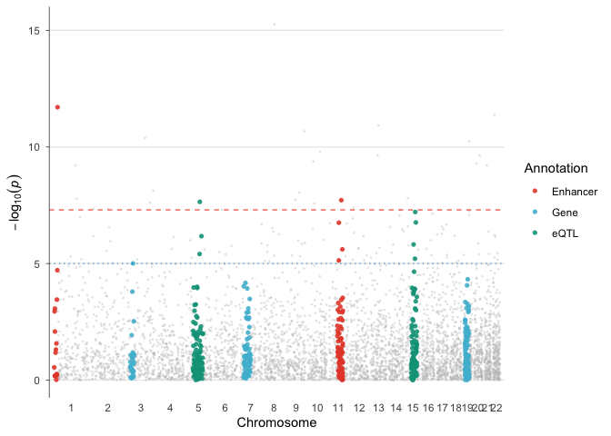

```r
annotations <- data.frame(
  chr = c(1, 3, 5, 7, 11, 15, 19),
  start = c(5e6, 20e6, 50e6, 30e6, 60e6, 40e6, 10e6),
  end = c(30e6, 50e6, 120e6, 80e6, 100e6, 80e6, 40e6),
  category = c("Enhancer", "Gene", "eQTL", "Gene",
               "Enhancer", "eQTL", "Gene")
)

enrichment_manhattan(example_gwas, annotations = annotations, palette = "nature")
```

## Circular Manhattan (multi-ring)

```r
circular_manhattan(
  list(BMI = example_gwas, Height = trait2),
  colors = "nature", point_size = 0.6
)
```

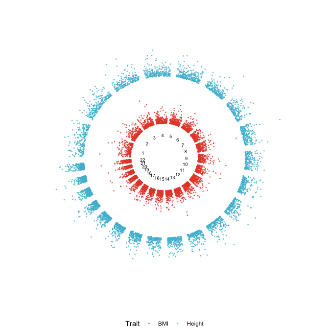

# Themes, palettes, and presets

## Color palettes

14 built-in palettes, all colorblind-safe:

```r
gwas_palettes()
```

```
#>  [1] "default"       "colorblind"    "vibrant"       "pastel"
#>  [5] "dark"          "nature"        "science"       "lancet"
#>  [9] "nejm"          "aaas"          "brewer_set1"   "brewer_set2"
#> [13] "brewer_paired" "brewer_dark2"
```

```r
gwas_palette("nature", n = 5)
```

```
#> [1] "#E64B35" "#4DBBD5" "#00A087" "#3C5488" "#F39B7F"
```

## Journal themes

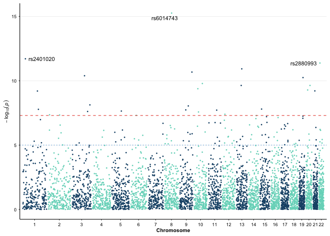

```r
manhattan_plot(example_gwas, label_top_n = 3) + theme_nature()
```

Available: `theme_nature()`, `theme_science()`, `theme_cell()`, `theme_plos()`, `theme_presentation()`, `theme_poster()`.

## Presets

A preset bundles a theme, palette, and point sizes:

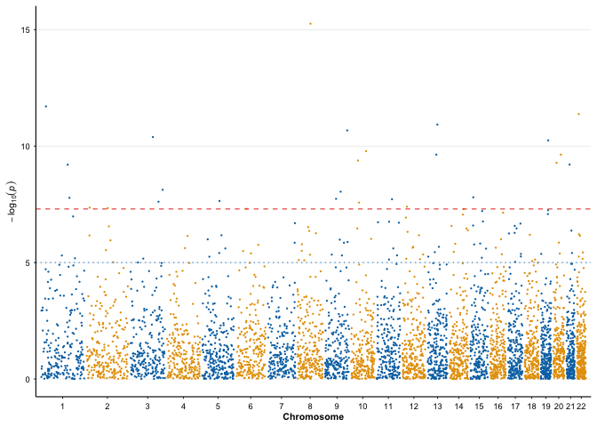

```r
p <- gwas_preset("publication")
manhattan_plot(example_gwas, colors = p$colors, point_size = p$point_size) + p$theme
```

Options: `"publication"`, `"presentation"`, `"poster"`, `"exploratory"`.

# Performance

Smart downsampling kicks in automatically above 200k variants. It keeps every significant SNP and bins the rest — the plot looks identical but renders much faster:

```r
manhattan_plot(large_gwas)                       # auto
manhattan_plot(large_gwas, downsample = FALSE)   # all points
manhattan_plot(large_gwas, downsample_n = 500000) # custom target
```

# Multi-panel figures

Every function returns a ggplot, so `patchwork` works out of the box:

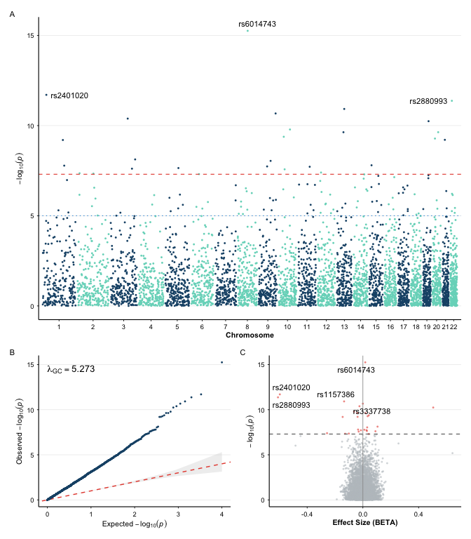

```r
library(patchwork)

p1 <- manhattan_plot(example_gwas, label_top_n = 3) +
  labs(tag = "A") + theme_nature()
p2 <- qq_plot(example_gwas) +
  labs(tag = "B") + theme_nature()
p3 <- volcano_plot(example_gwas, label_top_n = 5) +
  labs(tag = "C") + theme_nature()

p1 / (p2 | p3) + plot_layout(heights = c(2, 1))
```

# Saving

```r
fig <- manhattan_plot(example_gwas, label_top_n = 5) + theme_nature()
ggsave("figure1.pdf", fig, width = 89, height = 55, units = "mm")
```